# Life Insurance Survival Analysis: Basic Exploratory Methods

Kaplan-Meier Estimation, Log-Rank Tests, and Risk Stratification

Author

Mick Cooney

Published

January 9, 2026

# 1 Introduction

This worksheet provides practical exploratory survival analysis methods applied to life insurance policy lapse prediction. Rather than diving into statistical theory, we focus on core techniques for understanding how policyholder characteristics relate to policy persistence.

We’ll estimate overall and stratified survival curves (Kaplan-Meier method), test for differences between groups (log-rank test), and explore risk stratification to identify high-risk and low-risk populations.

# 2 Data Setup

We load pre-prepared training and validation datasets created in the exploration notebook. These datasets include all necessary variables and have been constructed following proper rollback methodology to ensure temporal consistency.

```r
# Load training data (snapshot at 2015-01-01)
training_tbl <- read_parquet("data/model_training_small_tbl.parquet")

# Load validation data (same policies at 2016-01-01)
validation_tbl <- read_parquet("data/model_rollforward_small_tbl.parquet")

write_log_entry(
  "DATA_LOAD",
  glue(
    "Loaded {nrow(training_tbl)} training, ",
    "{nrow(validation_tbl)} validation"
  )
)

# Quick structural check
training_tbl |> glimpse()
```

```
Rows: 10,000
Columns: 34
$ policy_id                <chr> "C010003609", "C010024702", "C010029925", "C0…
$ countyname               <chr> "Galway County", "Roscommon County", "Wexford…
$ edname                   <chr> "Na Forbacha", "Kilglass North", "Adamstown",…
$ nuts3name                <chr> "West", "West", "South-East (IE)", "South-Wes…
$ sa_id                    <chr> "A067097004", "A197071001", "A247001002", "A0…
$ cluster_id               <chr> "n6_c4", "n6_c1", "n6_c3", "n6_c2", "n6_c3", …
$ prod_type                <fct> protection, protection, protection, protectio…
$ prem_type                <chr> "RP", "RP", "RP", "RP", "RP", "RP", "RP", "RP…
$ prem_freq                <chr> "12", "12", "12", "12", "12", "12", "12", "12…
$ prem_ape                 <dbl> 2534.75, 953.35, 3061.69, 1460.54, 291.12, 45…
$ prem_risk                <dbl> 1810.5334, 680.9644, 2186.9235, 1043.2413, 20…
$ policy_startdate         <date> 1990-01-03, 1990-01-24, 1990-01-30, 1990-02-…
$ policy_enddate           <date> 2010-01-03, 2010-01-24, 2005-01-30, 2000-02-…
```

[output cut: 21 more lines]

# 3 Sanity Checks

We validate that policy status follows expected patterns: once a policy lapses or completes, it cannot revert to an active status.

```r
# Check unique status values
write_lines("Training dataset status distribution:", stdout())
```

```
Training dataset status distribution:
```

```r
training_tbl |>
  count(status_at_reference_date) |>
  mutate(prop = scales::percent(n / sum(n))) |>
  print()
```

```
# A tibble: 3 × 3
  status_at_reference_date     n prop
  <chr>                    <int> <chr>
1 completed                 1027 10%
2 inforce                   2746 27%
3 lapsed                    6227 62%
```

```r
write_lines("\nValidation dataset status distribution:", stdout())
```

```
Validation dataset status distribution:
```

```r
validation_tbl |>
  count(status_at_reference_date) |>
  mutate(prop = scales::percent(n / sum(n))) |>
  print()
```

```
# A tibble: 3 × 3
  status_at_reference_date     n prop
  <chr>                    <int> <chr>
1 completed                 1126 11%
2 inforce                   2393 24%
3 lapsed                    6481 65%
```

```r
# Verify terminal status logic
status_transitions <- training_tbl |>
  inner_join(
    validation_tbl |>
      select(policy_id, status_at_reference_date),
    by = "policy_id",
    relationship = "one-to-one",
    suffix = c("_train", "_valid")
  ) |>
  count(status_at_reference_date_train, status_at_reference_date_valid) |>
  rename(
    Training = status_at_reference_date_train,
    Validation = status_at_reference_date_valid,
    Count = n
  )

write_lines("\nStatus transitions from 2015 to 2016:", stdout())
```

```
Status transitions from 2015 to 2016:
```

```r
print(status_transitions)
```

```
# A tibble: 5 × 3
  Training  Validation Count
  <chr>     <chr>      <int>
1 completed completed   1027
2 inforce   completed     99
3 inforce   inforce     2393
4 inforce   lapsed       254
5 lapsed    lapsed      6227
```

```r
# Check that lapsed/completed don't revert to active
invalid_transitions <- training_tbl |>
  inner_join(
    validation_tbl |>
      select(policy_id, status_at_reference_date),
    by = "policy_id",
    relationship = "one-to-one",
    suffix = c("_train", "_valid")
  ) |>
  filter(
    (status_at_reference_date_train %in% c("lapsed", "completed")) &
    (status_at_reference_date_valid == "active")
  ) |>
  nrow()

if (invalid_transitions > 0) {
  write_log_entry("ERROR", glue("{invalid_transitions} invalid status transitions detected!"))
} else {
  write_log_entry("VALIDATION", "All status transitions valid (no reversals)")
}
```

# 4 Overall Survival Estimation

We begin with the simplest analysis: estimate the overall survival curve for all policies, regardless of characteristics. This establishes the baseline—what proportion of policies remain active at each duration?

```r
# Create Kaplan-Meier estimate for all policies
overall_km <- survfit(
  Surv(policy_lifetime, lapsed) ~ 1,
  data = training_tbl,
  conf.type = "log-log"
)

# Print summary - restricted to 4-week intervals over 2 years
overall_km |> summary(times = seq(0, 104, by = 4))
```

```
Call: survfit(formula = Surv(policy_lifetime, lapsed) ~ 1, data = training_tbl,
    conf.type = "log-log")

 time n.risk n.event survival std.err lower 95% CI upper 95% CI
    0  10000       0    1.000 0.00000        1.000        1.000
    4   9990      16    0.998 0.00040        0.997        0.999
    8   9835     115    0.987 0.00114        0.984        0.989
   12   9678     138    0.973 0.00162        0.970        0.976
   16   9548     109    0.962 0.00191        0.958        0.966
   20   9428     102    0.952 0.00215        0.947        0.956
   24   9305     113    0.940 0.00238        0.936        0.945
   28   9183     114    0.929 0.00258        0.924        0.934
   32   9040     114    0.917 0.00277        0.912        0.923
   36   8913      96    0.908 0.00291        0.902        0.913
   40   8782     110    0.896 0.00306        0.890        0.902
```

[output cut: 16 more lines]

## 4.1 Overall Survival Curve

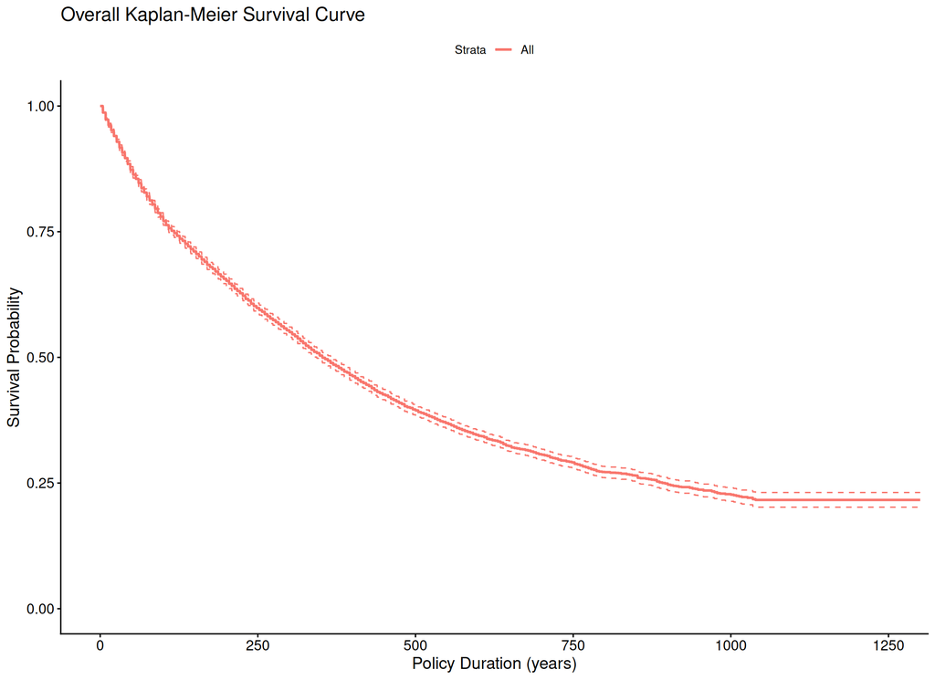

```r
overall_km |>
  ggsurvplot(
    censor = FALSE,
    conf.int = TRUE,
    conf.int.style = "step",
    title = "Overall Kaplan-Meier Survival Curve",
    xlab = "Policy Duration (years)",
    ylab = "Survival Probability"
  )
```

# 5 Stratified Survival Analysis

Real-world insights emerge when we compare survival across groups. We examine whether demographic and policy characteristics relate to lapse risk. This analysis typically reveals important risk factors for business decision-making.

## 5.1 Gender

Do male and female policyholders have different lapse experiences?

```r
# Create KM estimates stratified by gender
gender_km <- survfit(
  Surv(policy_lifetime, lapsed) ~ gender_life1,
  data = training_tbl,
  conf.type = "log-log"
)

# Print summary with stratification - restricted to 4-week intervals over 2 years
gender_km |> summary(times = seq(0, 104, by = 4))
```

```
Call: survfit(formula = Surv(policy_lifetime, lapsed) ~ gender_life1,
    data = training_tbl, conf.type = "log-log")

                gender_life1=F
 time n.risk n.event survival  std.err lower 95% CI upper 95% CI
    0   2991       0    1.000 0.000000        1.000        1.000
    4   2987       2    0.999 0.000473        0.997        1.000
    8   2953      25    0.991 0.001732        0.987        0.994
   12   2900      49    0.975 0.002887        0.968        0.980
   16   2870      24    0.966 0.003299        0.959        0.972
   20   2832      32    0.956 0.003774        0.948        0.962
   24   2806      21    0.949 0.004051        0.940        0.956
   28   2774      30    0.938 0.004411        0.929        0.946
   32   2727      38    0.926 0.004820        0.915        0.934
   36   2697      26    0.917 0.005075        0.906        0.926
```

[output cut: 47 more lines]

### 5.1.1 Gender Survival Curves

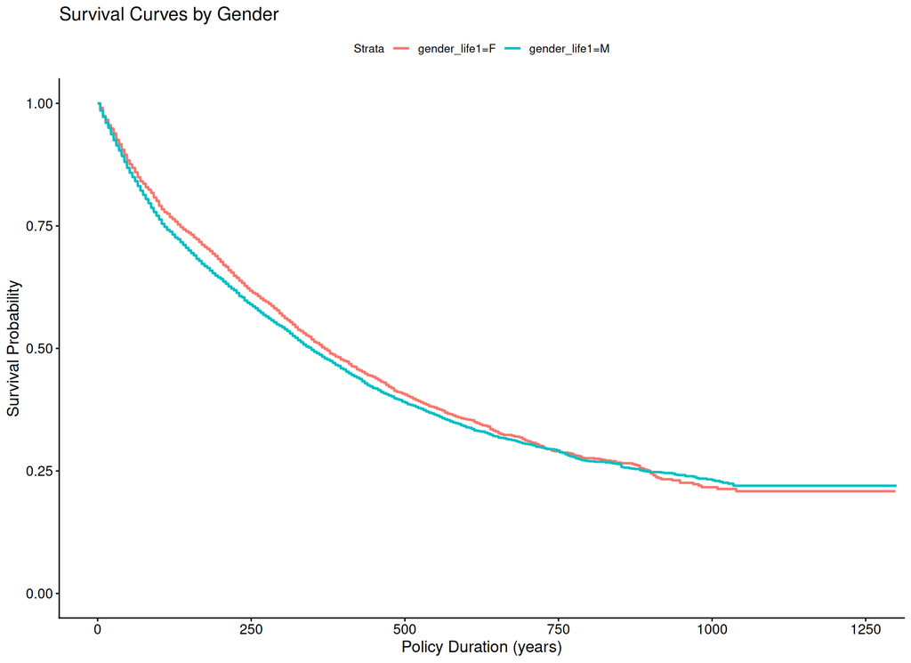

```r
gender_km |>
  ggsurvplot(
    censor = FALSE,
    conf.int = FALSE,
    title = "Survival Curves by Gender",
    xlab = "Policy Duration (years)",
    ylab = "Survival Probability"
  )
```

### 5.1.2 Gender Difference Testing

To test whether the observed difference in survival curves is statistically significant, we use the log-rank test:

```r
gender_survdiff <- survdiff(
  Surv(policy_lifetime, lapsed) ~ gender_life1,
  data = training_tbl
)

gender_survdiff |> print()
```

```
Call:
survdiff(formula = Surv(policy_lifetime, lapsed) ~ gender_life1,
    data = training_tbl)

                  N Observed Expected (O-E)^2/E (O-E)^2/V
gender_life1=F 2991     1850     1914     2.138       3.1
gender_life1=M 7009     4377     4313     0.949       3.1

 Chisq= 3.1  on 1 degrees of freedom, p= 0.08
```

```r
write_lines("\nSummary Statistics by Gender:", stdout())
```

```
Summary Statistics by Gender:
```

```r
training_tbl |>
  group_by(gender_life1) |>
  summarise(
    count = n(),
    lapsed_count = sum(lapsed),
    lapse_rate = scales::percent(mean(lapsed), accuracy = 0.1),
    mean_duration = mean(policy_lifetime),
    median_duration = median(policy_lifetime),
    .groups = "drop"
  ) |>
  print()
```

```
# A tibble: 2 × 6
  gender_life1 count lapsed_count lapse_rate mean_duration median_duration
  <chr>        <int>        <int> <chr>              <dbl>           <dbl>
1 F             2991         1850 61.9%               353.            304.
2 M             7009         4377 62.4%               337.            283.
```

## 5.2 Smoker Status

Does smoking status relate to lapse probability?

```r
smoker_km <- survfit(
  Surv(policy_lifetime, lapsed) ~ smoker_life1,
  data = training_tbl,
  conf.type = "log-log"
)

smoker_km |> summary(times = seq(0, 104, by = 4))
```

```
Call: survfit(formula = Surv(policy_lifetime, lapsed) ~ smoker_life1,
    data = training_tbl, conf.type = "log-log")

                smoker_life1=N
 time n.risk n.event survival  std.err lower 95% CI upper 95% CI
    0   4584       0    1.000 0.000000        1.000        1.000
    4   4581       5    0.999 0.000488        0.997        1.000
    8   4515      52    0.988 0.001638        0.984        0.990
   12   4454      52    0.976 0.002254        0.971        0.980
   16   4386      57    0.964 0.002768        0.958        0.969
   20   4330      46    0.954 0.003115        0.947        0.959
   24   4275      52    0.942 0.003459        0.935        0.949
   28   4215      59    0.929 0.003803        0.921        0.936
   32   4149      50    0.918 0.004066        0.910        0.926
   36   4087      42    0.909 0.004271        0.900        0.917
```

[output cut: 77 more lines]

### 5.2.1 Smoker Status Survival Curves

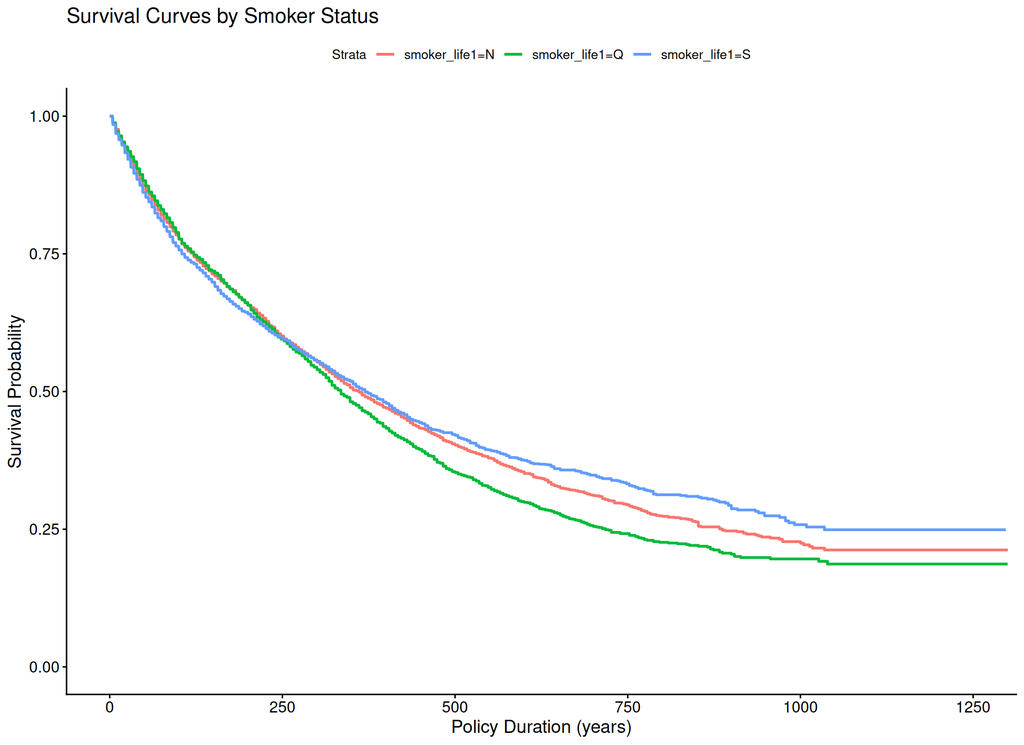

```r
smoker_km |>
  ggsurvplot(
    censor = FALSE,
    conf.int = FALSE,
    title = "Survival Curves by Smoker Status",
    xlab = "Policy Duration (years)",
    ylab = "Survival Probability"
  )
```

### 5.2.2 Smoker Status Difference Testing

```r
smoker_survdiff <- survdiff(
  Surv(policy_lifetime, lapsed) ~ smoker_life1,
  data = training_tbl
)

smoker_survdiff |> print()
```

```
Call:
survdiff(formula = Surv(policy_lifetime, lapsed) ~ smoker_life1,
    data = training_tbl)

                  N Observed Expected (O-E)^2/E (O-E)^2/V
smoker_life1=N 4584     2833     2871     0.508     0.945
smoker_life1=Q 2649     1744     1615    10.252    13.894
smoker_life1=S 2767     1650     1740     4.706     6.554

 Chisq= 15.5  on 2 degrees of freedom, p= 4e-04
```

```r
write_lines("\nSummary Statistics by Smoker Status:", stdout())
```

```
Summary Statistics by Smoker Status:
```

```r
training_tbl |>
  group_by(smoker_life1) |>
  summarise(
    count = n(),
    lapsed_count = sum(lapsed),
    lapse_rate = scales::percent(mean(lapsed), accuracy = 0.1),
    mean_duration = mean(policy_lifetime),
    median_duration = median(policy_lifetime),
    .groups = "drop"
  ) |>
  print()
```

```
# A tibble: 3 × 6
  smoker_life1 count lapsed_count lapse_rate mean_duration median_duration
  <chr>        <int>        <int> <chr>              <dbl>           <dbl>
1 N             4584         2833 61.8%               344.            295.
2 Q             2649         1744 65.8%               332.            283.
3 S             2767         1650 59.6%               348.            292
```

## 5.3 Policy Vintage Year

Do policies from different inception years show different lapse patterns? This can reflect changing underwriting, market conditions, or product modifications.

```r
vintage_km <- survfit(
  Surv(policy_lifetime, lapsed) ~ policy_vintage_year,
  data = training_tbl,
  conf.type = "log-log"
)

vintage_km |> summary(times = seq(0, 104, by = 4))
```

```
Call: survfit(formula = Surv(policy_lifetime, lapsed) ~ policy_vintage_year,
    data = training_tbl, conf.type = "log-log")

                policy_vintage_year=1990
 time n.risk n.event survival std.err lower 95% CI upper 95% CI
    0     94       0    1.000  0.0000        1.000        1.000
    4     94       0    1.000  0.0000        1.000        1.000
    8     94       0    1.000  0.0000        1.000        1.000
   12     93       1    0.989  0.0106        0.927        0.998
   16     90       3    0.957  0.0208        0.891        0.984
   20     90       0    0.957  0.0208        0.891        0.984
   24     90       0    0.957  0.0208        0.891        0.984
   28     90       0    0.957  0.0208        0.891        0.984
   32     89       1    0.947  0.0231        0.877        0.978
   36     88       1    0.936  0.0252        0.863        0.971
```

[output cut: 723 more lines]

### 5.3.1 Vintage Year Survival Curves

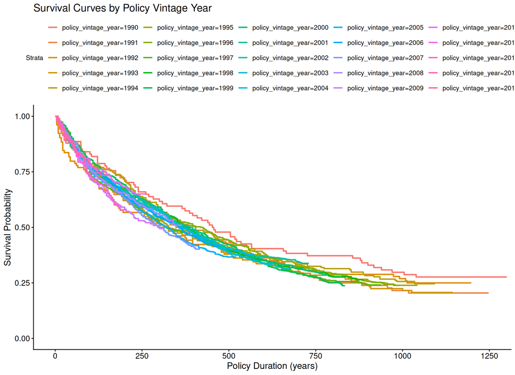

```r
vintage_km |>
  ggsurvplot(
    censor = FALSE,
    conf.int = FALSE,
    title = "Survival Curves by Policy Vintage Year",
    xlab = "Policy Duration (years)",
    ylab = "Survival Probability"
  )
```

### 5.3.2 Vintage Year Difference Testing

```r
vintage_survdiff <- survdiff(
  Surv(policy_lifetime, lapsed) ~ policy_vintage_year,
  data = training_tbl
)

vintage_survdiff |> print()
```

```
Call:
survdiff(formula = Surv(policy_lifetime, lapsed) ~ policy_vintage_year,
    data = training_tbl)

                           N Observed Expected (O-E)^2/E (O-E)^2/V
policy_vintage_year=1990  94       68     83.0  2.722057  2.787045
policy_vintage_year=1991  88       70     69.5  0.004190  0.004265
policy_vintage_year=1992 104       78     78.3  0.001261  0.001289
policy_vintage_year=1993 116       92     89.3  0.084126  0.086033
policy_vintage_year=1994 191      144    158.3  1.295926  1.349212
policy_vintage_year=1995 297      226    232.0  0.155320  0.163742
policy_vintage_year=1996 370      280    295.1  0.768083  0.817437
policy_vintage_year=1997 476      361    352.0  0.230764  0.247588
policy_vintage_year=1998 565      413    425.1  0.342146  0.371325
policy_vintage_year=1999 633      476    476.2  0.000102  0.000111
policy_vintage_year=2000 595      420    427.6  0.136767  0.148150
policy_vintage_year=2001 641      421    455.3  2.582264  2.811754
policy_vintage_year=2002 677      461    463.7  0.015739  0.017148
policy_vintage_year=2003 721      478    475.8  0.010107  0.011045
policy_vintage_year=2004 731      451    466.2  0.493200  0.538967
policy_vintage_year=2005 651      411    381.0  2.358368  2.540154
policy_vintage_year=2006 761      438    434.6  0.027143  0.029645
policy_vintage_year=2007 735      429    377.3  7.078851  7.676717
policy_vintage_year=2008 330      158    161.4  0.070388  0.073132
policy_vintage_year=2009 215      106     89.6  3.021606  3.096792
policy_vintage_year=2010 226       78     88.5  1.247591  1.281678
policy_vintage_year=2011 160       65     51.2  3.744761  3.817617
policy_vintage_year=2012 173       44     46.3  0.112977  0.115365
policy_vintage_year=2013 152       32     28.8  0.365154  0.371956
policy_vintage_year=2014 298       27     21.1  1.627835  1.670415

 Chisq= 29.5  on 24 degrees of freedom, p= 0.2
```

```r
write_lines("\nLapse Rates by Policy Vintage Year:", stdout())
```

```
Lapse Rates by Policy Vintage Year:
```

```r
training_tbl |>
  group_by(policy_vintage_year) |>
  summarise(
    count = n(),
    lapsed_count = sum(lapsed),
    lapse_rate = scales::percent(mean(lapsed), accuracy = 0.1),
    mean_duration = mean(policy_lifetime),
    median_duration = median(policy_lifetime),
    .groups = "drop"
  ) |>
  arrange(policy_vintage_year) |>
  print()
```

```
# A tibble: 25 × 6
   policy_vintage_year count lapsed_count lapse_rate mean_duration
                 <dbl> <int>        <int> <chr>              <dbl>
 1                1990    94           68 72.3%               609.
 2                1991    88           70 79.5%               510.
 3                1992   104           78 75.0%               493.
 4                1993   116           92 79.3%               478.
 5                1994   191          144 75.4%               511.
 6                1995   297          226 76.1%               471.
 7                1996   370          280 75.7%               475.
 8                1997   476          361 75.8%               431.
 9                1998   565          413 73.1%               436.
10                1999   633          476 75.2%               426.
# ℹ 15 more rows
# ℹ 1 more variable: median_duration <dbl>
```

# 6 Risk Stratification via Continuous Variable

Discretization

Policy characteristics like premium amount and sum assured are continuous, yet grouping policyholders into risk tiers aids interpretation and business application. We discretize key variables into meaningful categories.

## 6.1 Premium Amount Stratification

We create risk tiers based on premium amount:

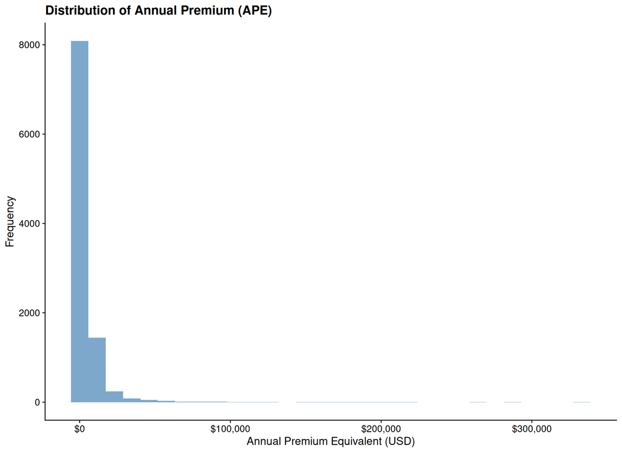

```r
# Examine distribution
training_tbl |>
  ggplot(aes(x = prem_ape)) +
  geom_histogram(bins = 30, fill = "steelblue", alpha = 0.7) +
  scale_x_continuous(labels = scales::label_dollar()) +
  labs(
    title = "Distribution of Annual Premium (APE)",
    x = "Annual Premium Equivalent (USD)",
    y = "Frequency"
  )
```

```r
# Create risk tiers based on business judgment
training_tbl_premium <- training_tbl |>
  mutate(
    premium_tier = cut(
      prem_ape,
      breaks = quantile(
        prem_ape,
        probs = c(0, 0.33, 0.67, 1.0)
      ),
      labels = c("Low", "Medium", "High"),
      include.lowest = TRUE
    )
  )

# Verify distribution
training_tbl_premium |>
  count(premium_tier) |>
  mutate(pct = scales::percent(n / sum(n))) |>
  print()
```

```
# A tibble: 3 × 3
  premium_tier     n pct
  <fct>        <int> <chr>
1 Low           3302 33.02%
2 Medium        3399 33.99%
3 High          3299 32.99%
```

### 6.1.1 Premium Tier Survival

```r
premium_km <- survfit(
  Surv(policy_lifetime, lapsed) ~ premium_tier,
  data = training_tbl_premium,
  conf.type = "log-log"
)

premium_km |> summary(times = seq(0, 104, by = 4))
```

```
Call: survfit(formula = Surv(policy_lifetime, lapsed) ~ premium_tier,
    data = training_tbl_premium, conf.type = "log-log")

                premium_tier=Low
 time n.risk n.event survival  std.err lower 95% CI upper 95% CI
    0   3302       0    1.000 0.000000        1.000        1.000
    4   3298       3    0.999 0.000525        0.997        1.000
    8   3256      30    0.990 0.001733        0.986        0.993
   12   3207      44    0.977 0.002634        0.971        0.981
   16   3169      32    0.967 0.003122        0.960        0.972
   20   3130      33    0.957 0.003548        0.949        0.963
   24   3081      47    0.942 0.004067        0.934        0.950
   28   3043      37    0.931 0.004423        0.922        0.939
   32   3004      31    0.922 0.004695        0.912        0.930
   36   2968      29    0.913 0.004933        0.902        0.922
```

[output cut: 77 more lines]

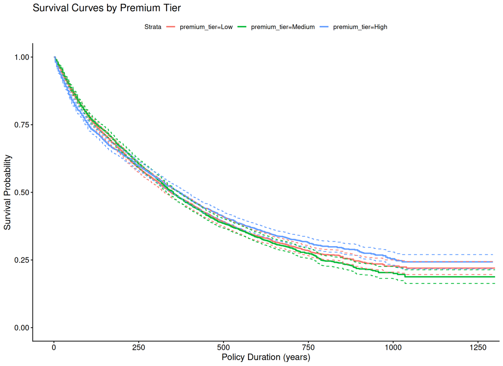

```r
premium_km |>
  ggsurvplot(
    censor = FALSE,
    conf.int = TRUE,
    conf.int.style = "step",
    title = "Survival Curves by Premium Tier",
    xlab = "Policy Duration (years)",
    ylab = "Survival Probability"
  )
```

### 6.1.2 Premium Tier Difference Testing

```r
premium_survdiff <- survdiff(
  Surv(policy_lifetime, lapsed) ~ premium_tier,
  data = training_tbl_premium
)

premium_survdiff |> print()
```

```
Call:
survdiff(formula = Surv(policy_lifetime, lapsed) ~ premium_tier,
    data = training_tbl_premium)

                       N Observed Expected (O-E)^2/E (O-E)^2/V
premium_tier=Low    3302     2082     2066     0.120     0.181
premium_tier=Medium 3399     2165     2126     0.702     1.070
premium_tier=High   3299     1980     2034     1.455     2.168

 Chisq= 2.3  on 2 degrees of freedom, p= 0.3
```

```r
write_lines("\nSummary Statistics by Premium Tier:", stdout())
```

```
Summary Statistics by Premium Tier:
```

```r
training_tbl_premium |>
  group_by(premium_tier) |>
  summarise(
    count = n(),
    lapsed_count = sum(lapsed),
    lapse_rate = scales::percent(mean(lapsed), accuracy = 0.1),
    mean_premium = scales::label_dollar()(mean(prem_ape)),
    mean_duration = mean(policy_lifetime),
    .groups = "drop"
  ) |>
  print()
```

```
# A tibble: 3 × 6
  premium_tier count lapsed_count lapse_rate mean_premium mean_duration
  <fct>        <int>        <int> <chr>      <chr>                <dbl>
1 Low           3302         2082 63.1%      $621.47               344.
2 Medium        3399         2165 63.7%      $1,993.59             342.
3 High          3299         1980 60.0%      $12,004.97            340.
```

## 6.2 Policy Amount Stratification

```r
# Create tiers for sum assured
training_tbl_sa <- training_tbl |>
  mutate(
    sa_tier = cut(
      sum_assured,
      breaks = quantile(
        sum_assured,
        probs = c(0, 0.33, 0.67, 1.0)
      ),
      labels = c("Low", "Medium", "High"),
      include.lowest = TRUE
    )
  )

# Verify distribution
training_tbl_sa |>
  count(sa_tier) |>
  mutate(pct = scales::percent(n / sum(n))) |>
  print()
```

```
# A tibble: 3 × 3
  sa_tier     n pct
  <fct>   <int> <chr>
1 Low      4286 42.9%
2 Medium   3078 30.8%
3 High     2636 26.4%
```

### 6.2.1 Sum Assured Tier Survival

```r
sa_km <- survfit(
  Surv(policy_lifetime, lapsed) ~ sa_tier,
  data = training_tbl_sa,
  conf.type = "log-log"
)

sa_km |> summary(times = seq(0, 104, by = 4))
```

```
Call: survfit(formula = Surv(policy_lifetime, lapsed) ~ sa_tier, data = training_tbl_sa,
    conf.type = "log-log")

                sa_tier=Low
 time n.risk n.event survival  std.err lower 95% CI upper 95% CI
    0   4286       0    1.000 0.000000        1.000        1.000
    4   4282       4    0.999 0.000467        0.998        1.000
    8   4227      37    0.990 0.001489        0.987        0.993
   12   4157      64    0.975 0.002370        0.970        0.980
   16   4110      40    0.966 0.002773        0.960        0.971
   20   4062      41    0.956 0.003128        0.950        0.962
   24   4008      51    0.944 0.003512        0.937        0.951
   28   3955      48    0.933 0.003831        0.925        0.940
   32   3896      43    0.923 0.004091        0.914        0.931
   36   3846      37    0.914 0.004300        0.905        0.922
```

[output cut: 77 more lines]

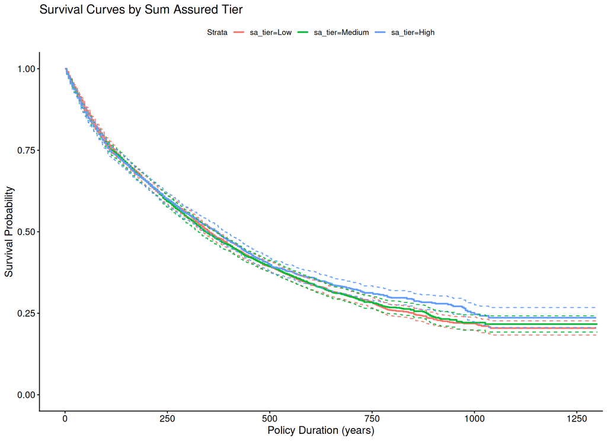

```r
sa_km |>
  ggsurvplot(
    censor = FALSE,
    conf.int = TRUE,
    conf.int.style = "step",
    title = "Survival Curves by Sum Assured Tier",
    xlab = "Policy Duration (years)",
    ylab = "Survival Probability"
  )
```

### 6.2.2 Sum Assured Tier Difference Testing

```r
sa_survdiff <- survdiff(
  Surv(policy_lifetime, lapsed) ~ sa_tier,
  data = training_tbl_sa
)

sa_survdiff |> print()
```

```
Call:
survdiff(formula = Surv(policy_lifetime, lapsed) ~ sa_tier, data = training_tbl_sa)

                  N Observed Expected (O-E)^2/E (O-E)^2/V
sa_tier=Low    4286     2684     2660     0.214     0.375
sa_tier=Medium 3078     1945     1918     0.372     0.540
sa_tier=High   2636     1598     1649     1.553     2.118

 Chisq= 2.1  on 2 degrees of freedom, p= 0.3
```

```r
write_lines("\nSummary Statistics by Sum Assured Tier:", stdout())
```

```
Summary Statistics by Sum Assured Tier:
```

```r
training_tbl_sa |>
  group_by(sa_tier) |>
  summarise(
    count = n(),
    lapsed_count = sum(lapsed),
    lapse_rate = scales::percent(mean(lapsed), accuracy = 0.1),
    mean_sa = scales::label_dollar()(mean(sum_assured)),
    mean_duration = mean(policy_lifetime),
    .groups = "drop"
  ) |>
  print()
```

```
# A tibble: 3 × 6
  sa_tier count lapsed_count lapse_rate mean_sa  mean_duration
  <fct>   <int>        <int> <chr>      <chr>            <dbl>
1 Low      4286         2684 62.6%      $177,205          340.
2 Medium   3078         1945 63.2%      $349,383          342.
3 High     2636         1598 60.6%      $960,907          345.
```

# 7 Hazard Rate Estimation

The hazard rate measures the instantaneous risk of lapse at each duration. While the Kaplan-Meier estimator focuses on survival probability, hazard rates help us understand *when* lapses occur—whether risk is concentrated early (early lapse risk) or spread across durations (ongoing maintenance risk).

```r
# Estimate smoothed hazard rates using muhaz
library(muhaz)

# Overall hazard
overall_hazard <- kphaz.fit(
  training_tbl$policy_lifetime,
  training_tbl$lapsed,
  method = "nelson"
)

# Hazard by gender
male_data <- training_tbl |> filter(gender_life1 == "M")
female_data <- training_tbl |> filter(gender_life1 == "F")

male_hazard <- kphaz.fit(
  male_data$policy_lifetime,
  male_data$lapsed,
  method = "nelson"
)

female_hazard <- kphaz.fit(
  female_data$policy_lifetime,
  female_data$lapsed,
  method = "nelson"
)
```

### 7.0.1 Overall Hazard Rate

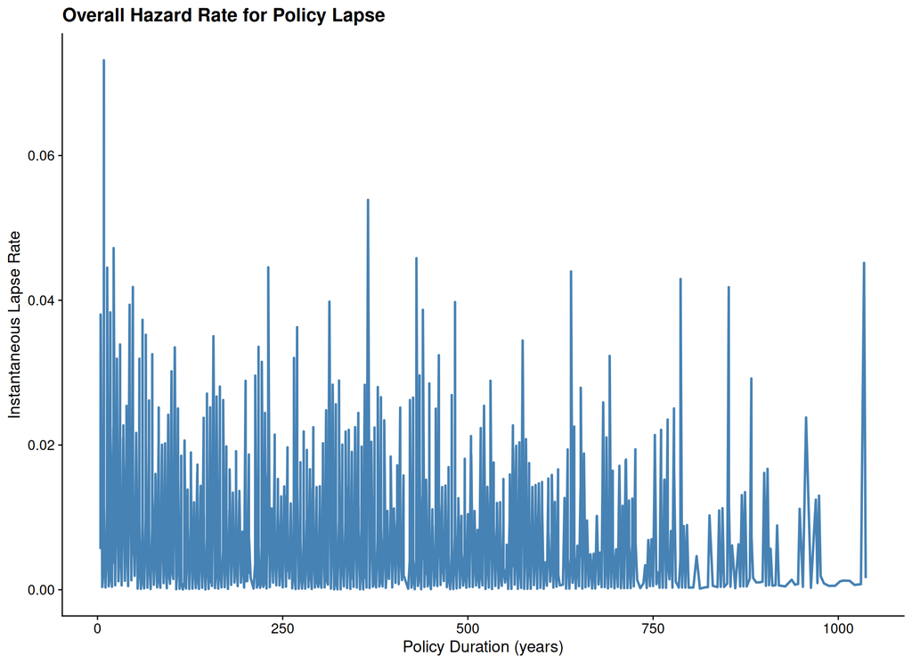

```r
# Create tibble for plotting
overall_hazard_tbl <- tibble(
  time = overall_hazard$time,
  hazard = overall_hazard$haz
)

ggplot(overall_hazard_tbl) +
  geom_line(aes(x = time, y = hazard), size = 1, color = "steelblue") +
  labs(
    title = "Overall Hazard Rate for Policy Lapse",
    x = "Policy Duration (years)",
    y = "Instantaneous Lapse Rate"
  )
```

The hazard curve reveals when lapses are most likely to occur. Early-peaked curves suggest lapse risk concentrates shortly after purchase; declining curves suggest risk decreases with duration; U-shaped curves combine both effects.

### 7.0.2 Hazard by Gender

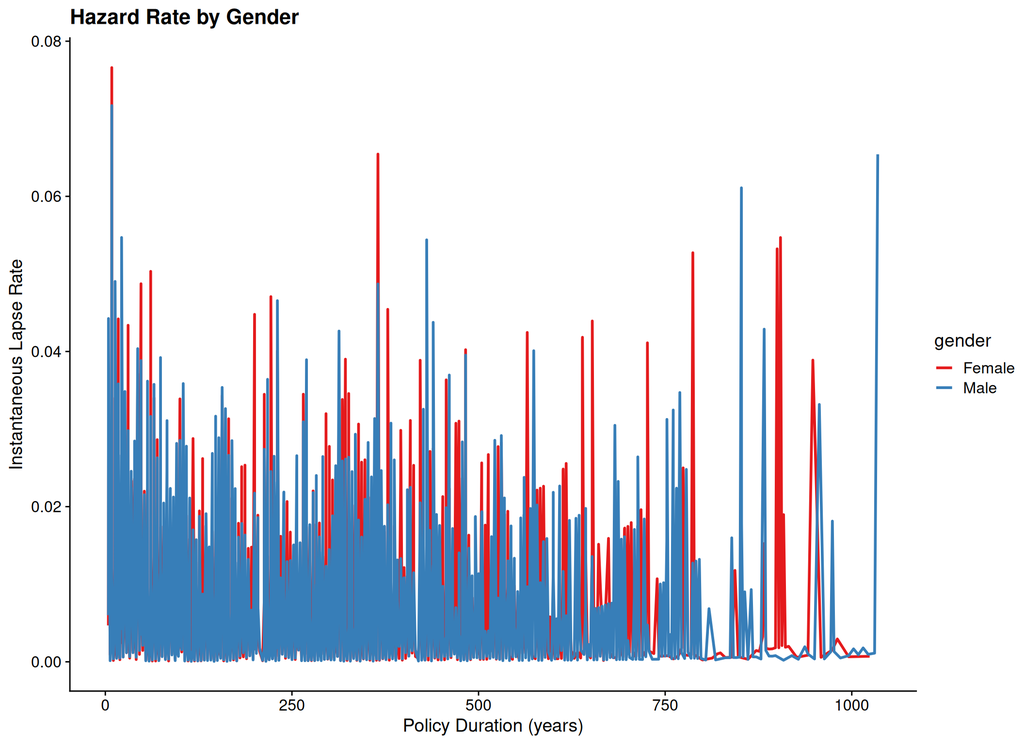

```r
gender_hazard_tbl <- bind_rows(
  tibble(
    time = male_hazard$time,
    hazard = male_hazard$haz,
    gender = "Male"
  ),
  tibble(
    time = female_hazard$time,
    hazard = female_hazard$haz,
    gender = "Female"
  )
)

ggplot(gender_hazard_tbl) +
  geom_line(aes(x = time, y = hazard, color = gender), size = 1) +
  scale_color_brewer(palette = "Set1") +
  labs(
    title = "Hazard Rate by Gender",
    x = "Policy Duration (years)",
    y = "Instantaneous Lapse Rate"
  )
```

# 8 Validation Period Comparison

After understanding survival patterns in the training period, we ask: do these patterns hold in the validation period? Comparing training and validation survival curves reveals whether our exploratory findings generalize.

```r
# Validation period survival
validation_km <- survfit(
  Surv(policy_lifetime, lapsed) ~ 1,
  data = validation_tbl,
  conf.type = "log-log"
)

# Extract curves for comparison using ggsurvplot outputs
training_km_obj <- ggsurvplot(
  survfit(Surv(policy_lifetime, lapsed) ~ 1, data = training_tbl),
  conf.int = TRUE,
  censor = FALSE
)

validation_km_obj <- ggsurvplot(
  survfit(Surv(policy_lifetime, lapsed) ~ 1, data = validation_tbl),
  conf.int = TRUE,
  censor = FALSE
)

training_km_data <- training_km_obj$plot$data |> mutate(period = "Training")
validation_km_data <- validation_km_obj$plot$data |>
  mutate(period = "Validation")
```

### 8.0.1 Comparing Training and Validation Survival

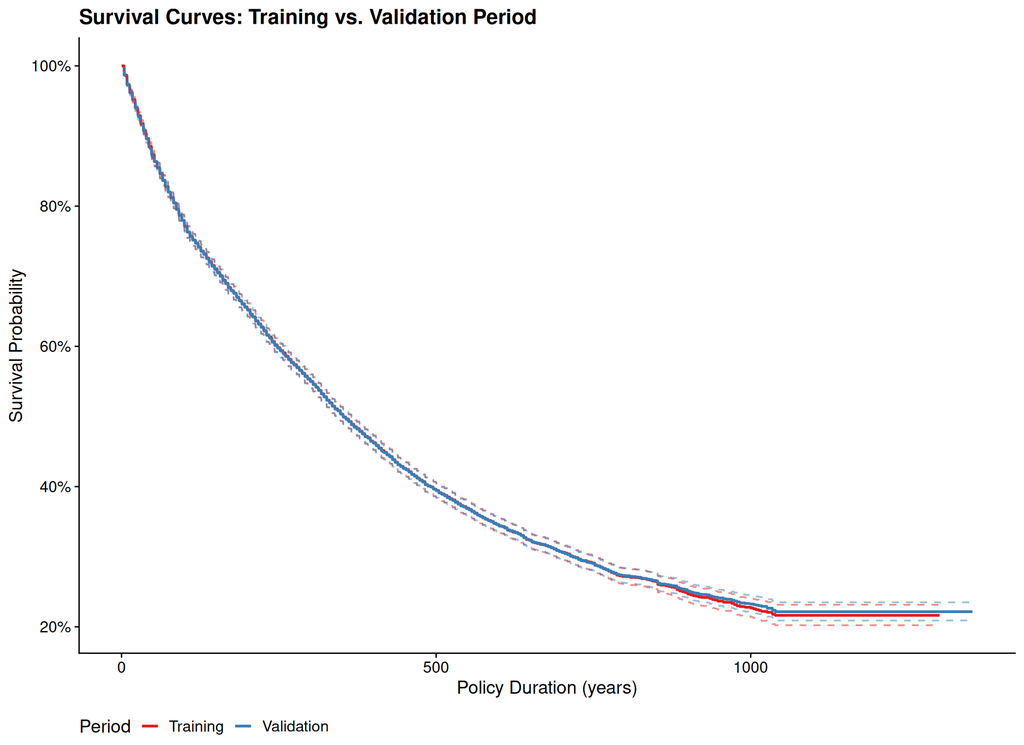

```r
# Manual KM curve comparison
train_km <- survfit(Surv(policy_lifetime, lapsed) ~ 1, data = training_tbl)
valid_km <- survfit(Surv(policy_lifetime, lapsed) ~ 1, data = validation_tbl)

# Combine tidy data for plotting
combined_km_tbl <- bind_rows(
  train_km |> tidy() |> mutate(period = "Training"),
  valid_km |> tidy() |> mutate(period = "Validation")
)

ggplot(combined_km_tbl) +
  geom_line(aes(x = time, y = estimate, color = period), size = 1) +
  geom_line(
    aes(x = time, y = conf.high, color = period),
    linetype = "dashed",
    alpha = 0.5
  ) +
  geom_line(
    aes(x = time, y = conf.low, color = period),
    linetype = "dashed",
    alpha = 0.5
  ) +
  scale_color_brewer(palette = "Set1") +
  scale_y_continuous(labels = scales::percent) +
  labs(
    title = "Survival Curves: Training vs. Validation Period",
    x = "Policy Duration (years)",
    y = "Survival Probability",
    color = "Period"
  ) +
  theme(legend.position = "bottom")
```

### 8.0.2 Validation Gender Comparison

```r
# Training period gender survival
train_gender_km <- survfit(
  Surv(policy_lifetime, lapsed) ~ gender_life1,
  data = training_tbl
)

# Validation period gender survival
valid_gender_km <- survfit(
  Surv(policy_lifetime, lapsed) ~ gender_life1,
  data = validation_tbl
)

# Compare via log-rank test
train_gender_diff <- survdiff(
  Surv(policy_lifetime, lapsed) ~ gender_life1,
  data = training_tbl
)

valid_gender_diff <- survdiff(
  Surv(policy_lifetime, lapsed) ~ gender_life1,
  data = validation_tbl
)

write_lines("Training Period Gender Comparison:", stdout())
```

```
Training Period Gender Comparison:
```

```r
train_gender_diff |> print()
```

```
Call:
survdiff(formula = Surv(policy_lifetime, lapsed) ~ gender_life1,
    data = training_tbl)

                  N Observed Expected (O-E)^2/E (O-E)^2/V
gender_life1=F 2991     1850     1914     2.138       3.1
gender_life1=M 7009     4377     4313     0.949       3.1

 Chisq= 3.1  on 1 degrees of freedom, p= 0.08
```

```r
write_lines("\n\nValidation Period Gender Comparison:", stdout())
```

```
Validation Period Gender Comparison:
```

```r
valid_gender_diff |> print()
```

```
Call:
survdiff(formula = Surv(policy_lifetime, lapsed) ~ gender_life1,
    data = validation_tbl)

                  N Observed Expected (O-E)^2/E (O-E)^2/V
gender_life1=F 2991     1934     1990      1.60      2.32
gender_life1=M 7009     4547     4491      0.71      2.32

 Chisq= 2.3  on 1 degrees of freedom, p= 0.1
```

# 9 Summary Insights

## 9.2 Interpretation and Business Implications

These univariate findings establish baseline understanding but don’t account for confounding. For instance, gender differences might reflect underlying age or health status differences rather than gender itself. Multivariate modelling (Cox regression) is needed to isolate independent effects of each variable while controlling for others.

## 9.3 Next Steps

The next worksheet shifts to **Cox proportional hazards models**, which allow us to:

1. Estimate independent effects of multiple variables simultaneously
2. Incorporate continuous variables directly without discretization loss
3. Generate individual-level risk predictions
4. Validate model assumptions and fit